# Analysis Report

#### Concrete

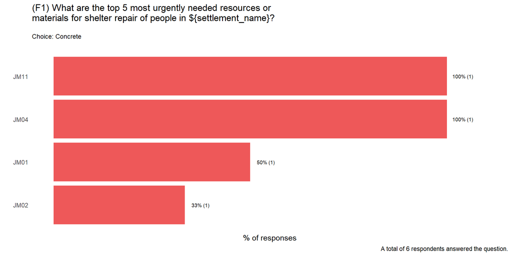

#### Cash to pay for repair materials and/or labor

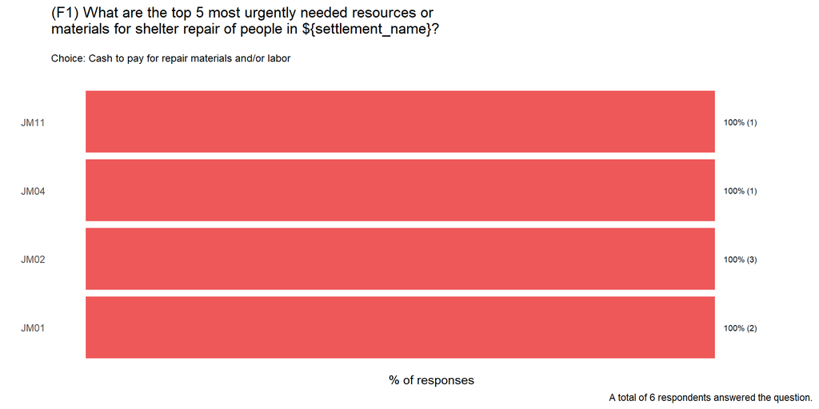

#### Basic tools (hammer, screwdriver, wrenches)

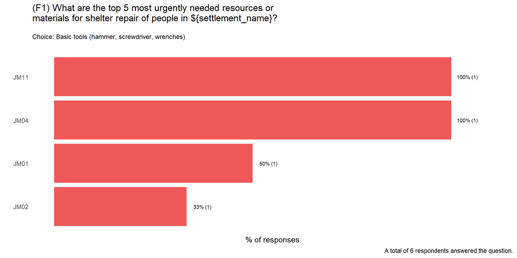

### (I3) Since the event, have there been problems that prevented any community members from purchasing food items at local marketplaces?

#### Yes, the food items people need are no longer available i…

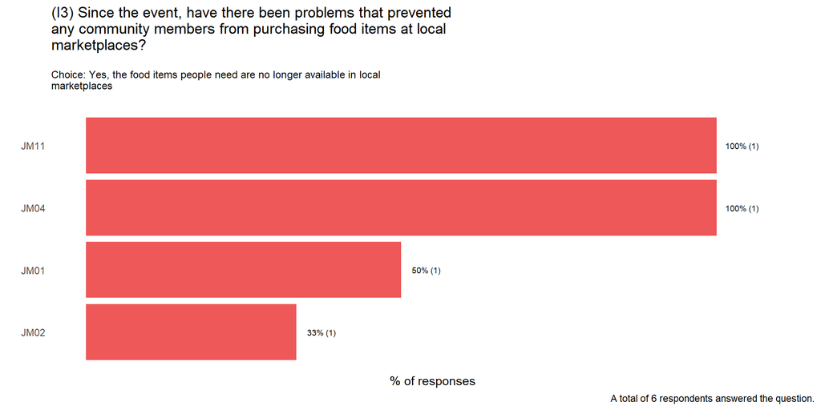

#### Yes, the food items people need were not available in loc…

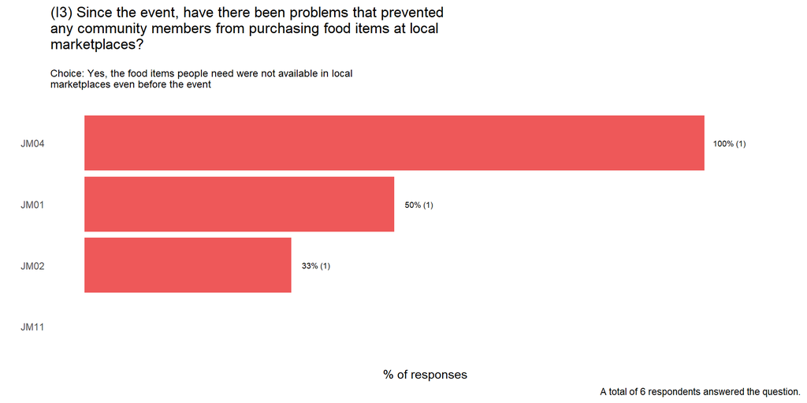

#### Yes, the food items people need have become too expensive…

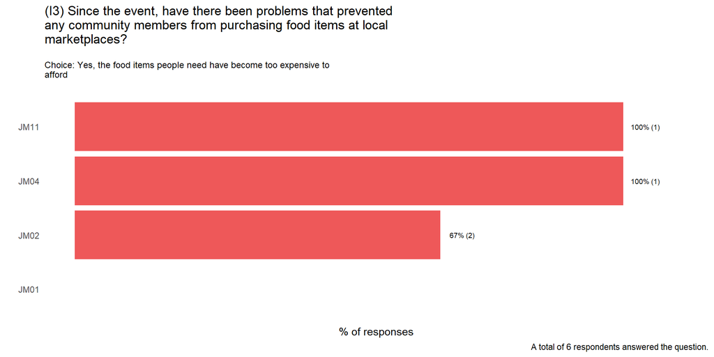